# Simple Inference

YC

## Estimating the width of a room

*Data from HSAUR*

```
##      unit width
## 43 metres    38
## 44 metres    40
## 45   feet    24
## 46   feet    25
## 47   feet    27
```

The data shown in the above table, as you can notice has estimates of room’s width in both meters and feet. Each estimate was recorded from multiple individuals who were in a country where ‘foot’ was used predominantly over ‘meter’.

If we convert meters to feet by multiplying each of them by a scalar factor of 3.28 then we would like to test the hypothesis that the mean of the population of ‘metre’ estimates is equal to the mean of the population of ‘feet’ estimates. We shall do this first by using an independent samples t-test, but first let’s check the normality and equal variance assumptions.

```r
convert <- ifelse(roomwidth$unit == "feet", 1, 3.28)
```

Now some summary stats

```r
tapply(roomwidth$width * convert, roomwidth$unit, summary)
```

```
## $feet
##    Min. 1st Qu.  Median    Mean 3rd Qu.    Max.
##    24.0    36.0    42.0    43.7    48.0    94.0
##
## $metres
##    Min. 1st Qu.  Median    Mean 3rd Qu.    Max.
##   26.24   36.08   49.20   52.55   55.76  131.20
```

standard deviation

```r
tapply(roomwidth$width * convert, roomwidth$unit, sd)
```

```
##     feet   metres
## 12.49742 23.43444
```

Now examine the data with some plots

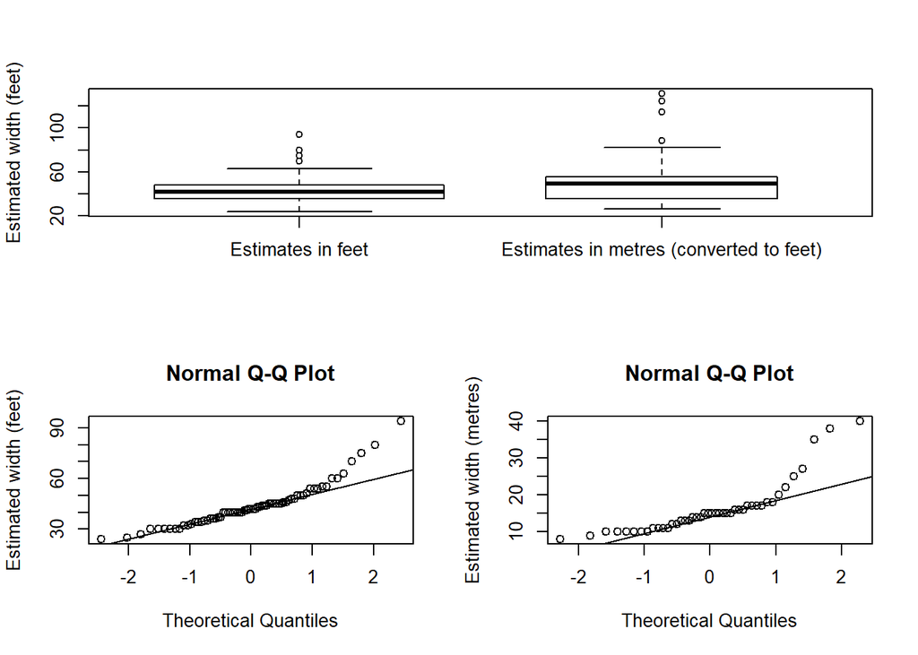

```r
layout(matrix(c(1, 2, 1, 3), nrow = 2, ncol = 2, byrow = FALSE))
boxplot(I(width * convert) ~ unit, data = roomwidth, ylab = "Estimated width (feet)", varwidth = TRUE,
names = c("Estimates in feet", "Estimates in metres (converted to feet)"))
feet <- roomwidth$unit == "feet"
metres <- roomwidth$unit == "metres"
qqnorm(roomwidth$width[feet], ylab = "Estimated width (feet)")
qqline(roomwidth$width[feet])
qqnorm(roomwidth$width[metres], ylab = "Estimated width (metres)")
qqline(roomwidth$width[metres])
```

Independent samples t-test

```r
t.test(I(width * convert) ~ unit, data = roomwidth, var.equal = TRUE)
```

```
##
##  Two Sample t-test
##
## data:  I(width * convert) by unit
## t = -2.6147, df = 111, p-value = 0.01017
## alternative hypothesis: true difference in means is not equal to 0
## 95 percent confidence interval:
##  -15.572734  -2.145052
## sample estimates:
##   mean in group feet mean in group metres
##             43.69565             52.55455
```

Independent samples Welch test (notice var.equal parameter set to FALSE)

```r
t.test(I(width * convert) ~ unit, data = roomwidth, var.equal = FALSE)
```

```
##
##  Welch Two Sample t-test
##
## data:  I(width * convert) by unit
## t = -2.3071, df = 58.788, p-value = 0.02459
## alternative hypothesis: true difference in means is not equal to 0
## 95 percent confidence interval:
##  -16.54308  -1.17471
## sample estimates:
##   mean in group feet mean in group metres
##             43.69565             52.55455
```

Wilcoxon rank sum test (non-parametric) for shaky assumptions case

```r
wilcox.test(I(width * convert) ~ unit, data = roomwidth, conf.int = TRUE)
```

```
##
##  Wilcoxon rank sum test with continuity correction
##
## data:  I(width * convert) by unit
## W = 1145, p-value = 0.02815
## alternative hypothesis: true location shift is not equal to 0
## 95 percent confidence interval:
##  -9.3599953 -0.8000423
## sample estimates:
## difference in location
##              -5.278598
```

## wave Energy Device Mooring

```r
waves[1:4,]
```

```
##   method1 method2
## 1    2.23    1.82
## 2    2.55    2.42
## 3    7.99    8.26
## 4    4.09    3.46
```

This data is Measurements of root mean square bending moment by two different mooring methods and requires matched pairs t-test to answer the question of interest. This test assumes that the differences between the matched observations have a normal distribution so we can begin by checking this assumption by constructing a boxplot and a normal probability plot

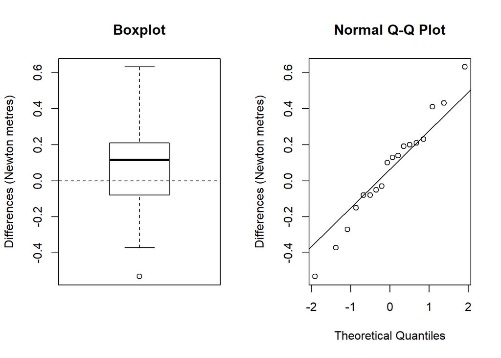

```r
mooringdiff <- waves$method1 - waves$method2
layout(matrix(1:2, ncol = 2))
boxplot(mooringdiff, ylab = "Differences (Newton metres)", main = "Boxplot")
abline(h = 0, lty = 2)
qqnorm(mooringdiff, ylab = "Differences (Newton metres)")
qqline(mooringdiff)
```

paired t-test for the waves data

```r
t.test(mooringdiff)
```

```
##
##  One Sample t-test
##
## data:  mooringdiff
## t = 0.90193, df = 17, p-value = 0.3797
## alternative hypothesis: true mean is not equal to 0
## 95 percent confidence interval:
##  -0.08258476  0.20591810
## sample estimates:
##  mean of x
## 0.06166667
```

Wilcoxon signed rank test

```r
wilcox.test(mooringdiff)
```

```
##
##  Wilcoxon signed rank test with continuity correction
##
## data:  mooringdiff
## V = 109, p-value = 0.3165
## alternative hypothesis: true location is not equal to 0
```

## Mortality and Water Hardness

```r
head(water)
```

```
##   location       town mortality hardness
## 1    South       Bath      1247      105
## 2    North Birkenhead      1668       17
## 3    South Birmingham      1466        5
## 4    North  Blackburn      1800       14
## 5    North  Blackpool      1609       18
## 6    North     Bolton      1558       10
```

This data is the mortality and drinking water hardness for 61 cities in England and Wales.

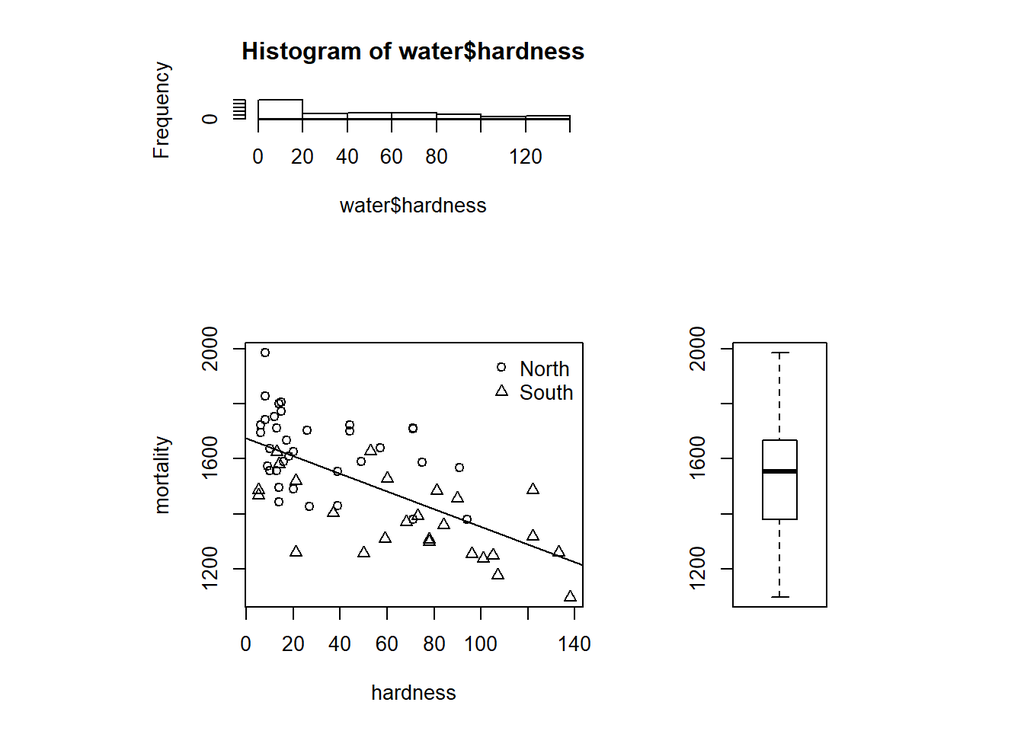

```r
nf <- layout(matrix(c(2, 0, 1, 3), 2, 2, byrow = TRUE), c(2, 1), c(1, 2), TRUE)
psymb <- as.numeric(water$location)
plot(mortality ~ hardness, data = water, pch = psymb)
abline(lm(mortality ~ hardness, data = water))
legend("topright", legend = levels(water$location), pch = c(1, 2), bty = "n")
hist(water$hardness)
boxplot(water$mortality)
```

Hardness shows it has a rather skewed distribution. Enhanced scatterplot of water hardness and mortality, showing both the joint and the marginal distributions and, in addition, the location of the city by different plotting symbols.

The scatterplot shows that as hardness increases mortality decreases, and the histogram for the water hardness shows it has a rather skewed distribution.

```r
cor.test(~mortality + hardness, data = water)
```

```
##
##  Pearson's product-moment correlation
##
## data:  mortality and hardness
## t = -6.6555, df = 59, p-value = 1.033e-08
## alternative hypothesis: true correlation is not equal to 0
## 95 percent confidence interval:
##  -0.7783208 -0.4826129
## sample estimates:
##        cor
## -0.6548486
```

## Piston-ring Failures

```r
head(pistonrings)
```

```
##           leg
## compressor North Centre South
##         C1    17     17    12
##         C2    11      9    13
##         C3    11      8    19
##         C4    14      7    28
```

Data describes number of failures of piston rings in three legs of four steam-driven compressors

Rather than looking at the simple differences of observed and expected values for each cell which would be unsatisfactory since a difference of fixed size is clearly more important for smaller samples, it is preferable to consider a standardised residual given by dividing the observed minus expected difference by the square root of the appropriate expected value. The X^2 statistic for assessing independence is simply the sum, over all the cells in the table, of the squares of these terms. We can find these values extracting the residuals element of the object returned by the chisq.test function.

```r
chisq.test(pistonrings)$residuals
```

```
##           leg
## compressor      North     Centre      South
##         C1  0.6036154  1.6728267 -1.7802243
##         C2  0.1429031  0.2975200 -0.3471197
##         C3 -0.3251427 -0.4522620  0.6202463
##         C4 -0.4157886 -1.4666936  1.4635235
```

Association plot of the residual

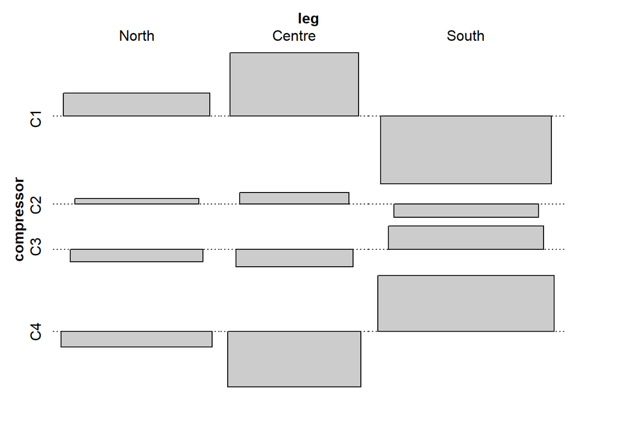

```r
library("vcd")
assoc(pistonrings)
```

Run Standard Chi-squared test

```r
chisq.test(pistonrings)
```

```
##
##  Pearson's Chi-squared test
##
## data:  pistonrings
## X-squared = 11.722, df = 6, p-value = 0.06846
```

## Rearrests of Juveniles

```r
head(rearrests)
```

```
##              Juvenile court
## Adult court   Rearrest No rearrest
##   Rearrest         158         515
##   No rearrest      290        1134
```

The data shows rearrests of juventile felons by type of court in which they were tried.

```r
mcnemar.test(rearrests, correct = FALSE)
```

```
##
##  McNemar's Chi-squared test
##
## data:  rearrests
## McNemar's chi-squared = 62.888, df = 1, p-value = 2.188e-15
```

Here we need to use McNemar’s test to assess whether rearrest is associated with type of court where the juvenile was tried. We can use the R function mcnemar.test. The test statistic is 62.888 with a single degree of freedom – the associated p-value is extremely small and there is strong evidence that type of court and the probability of rearrest are related. It appears that trial at a juvenile court is less likely to result in rearrest

```r
mcnemar.test(rearrests, correct = FALSE)
```

```
##
##  McNemar's Chi-squared test
##
## data:  rearrests
## McNemar's chi-squared = 62.888, df = 1, p-value = 2.188e-15
```

```r
binom.test(rearrests[2], n = sum(rearrests[c(2,3)]))
```

```
##
##  Exact binomial test
##
## data:  rearrests[2] and sum(rearrests[c(2, 3)])
## number of successes = 290, number of trials = 805, p-value =
## 1.918e-15
## alternative hypothesis: true probability of success is not equal to 0.5
## 95 percent confidence interval:
##  0.3270278 0.3944969
## sample estimates:
## probability of success
##              0.3602484
```

*Exact version of McNemar’s test for the rearrests data computed via a binomal test.*